# IV - Confidence intervals

## Sample proportion value effects on bootstrap CIs

One additional element that changes the width of the confidence interval is the sample parameter value, $\hat p$ .

Generally, when the true parameter is close to 0.5, the standard error of $\hat p$ is larger than when the true parameter is closer to 0 or 1. When calculating a bootstrap t-confidence interval, the standard error controls the width of the CI, and here (given a true parameter of 0.8) the sample proportion is higher than in previous exercises, so the width of the confidence interval will be narrower.

```r
calc_p_hat <- function(dataset) {
  dataset %>%
    summarize(stat = mean(vote == "yes")) %>%
    pull()
}
calc_t_conf_int <- function(resampled_dataset, p_hat) {
  resampled_dataset %>%
    summarize(
      lower = p_hat - 2 * sd(stat),
      upper = p_hat + 2 * sd(stat)
    )
}
```

```r
# Find proportion of yes votes from original population
p_hat <- calc_p_hat(one_poll)

# Review the value
p_hat
```

```
[1] 0.7
```

- Consider a new population where the true parameter is 0.8, one_poll_0.8. Calculate of this new sample, using the same technique as with the original dataset. Call it p_hat_0.8.
- Find the bootstrap t-confidence interval using the new bootstrapped data, one_poll_boot_0.8, and the new $\hat p$ . Notice that it is narrower than previously calculated.

```r
# Calculate bootstrap t-confidence interval (original 0.6 param)
calc_t_conf_int(one_poll_boot, p_hat)
```

| lower | upper |
| --- | --- |
| 0.5293272 | 0.8706728 |

```r
# Find proportion of yes votes from new population
p_hat_0.8 <- calc_p_hat(one_poll_0.8)

# Review the value
p_hat_0.8
```

```
[1] 0.8333333
```

```r
# Calculate the bootstrap t-confidence interval (new 0.8 param)
calc_t_conf_int(one_poll_boot_0.8, p_hat_0.8)
```

| lower | upper |
| --- | --- |
| 0.694982 | 0.9716847 |

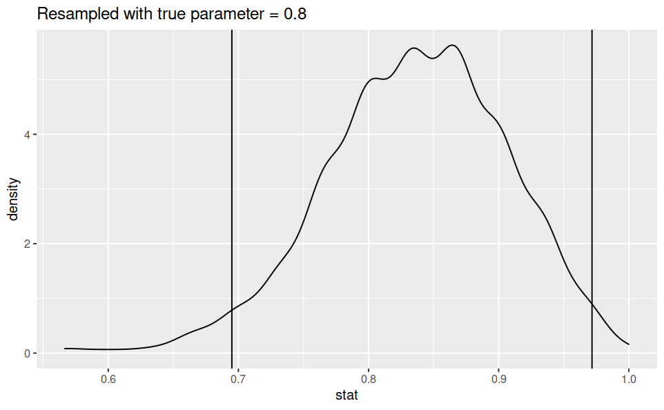

```r
conf_int = calc_t_conf_int(one_poll_boot_0.8, p_hat_0.8)
ggplot(one_poll_boot_0.8, aes(stat)) +
  geom_density() +
  geom_vline(xintercept = conf_int$lower) +
  geom_vline(xintercept = conf_int$upper) +
  ggtitle("Resampled with true parameter = 0.8")
```

The distribution saturates at both extremes 0 and 1, remembers its a ratio.

You have found the bootstrap t-confidence interval. Note that it’s narrower than previously calculated because the sample proportion itself was close to 1.

## Percentile effects on bootstrap CIs

Most scientists use 95% intervals to quantify their uncertainty about an estimate. That is, they understand that over a lifetime of creating confidence intervals, only 95% of them will actually contain the parameter that they set out to estimate.

There are studies, however, which warrant either stricter or more lenient confidence intervals (and subsequent error rates).

The previous bootstrapped $\hat p *$ values have been loaded for you and are available in one_poll_boot.

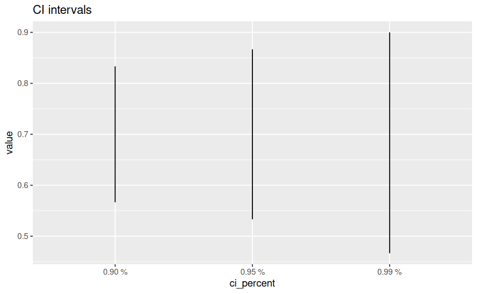

```r
# Calculate a 95% bootstrap percentile interval

conf_int_data = data.frame()

one_poll_boot %>%
  get_confidence_interval(level = 0.95) -> conf_int_0.95
conf_int_data = rbind(conf_int_data, c(conf_int_0.95, ci_percent = "0.95 %"))

# Calculate a 99% bootstrap percentile interval
one_poll_boot %>%
  get_confidence_interval(level = 0.99) -> conf_int_0.99
conf_int_data = rbind(conf_int_data, c(conf_int_0.99, ci_percent = "0.99 %"))

# Calculate a 90% bootstrap percentile interval
one_poll_boot %>%
  get_confidence_interval(level = 0.90) -> conf_int_0.90
conf_int_data = rbind(conf_int_data, c(conf_int_0.90, ci_percent = "0.90 %"))


reshape2::melt(conf_int_data) %>%
ggplot(aes(ci_percent, value)) +
  geom_line() +
  ggtitle("CI intervals")
```

# Summary of statistical inference

# ANEX I : Original Datacamp data dumped, por one_poll_boot_3 and 300

```r
one_poll_boot_3_dput   <- readRDS("./datasets/one_poll_boot_3.rds")
one_poll_boot_300_dput <- readRDS("./datasets/one_poll_boot_300.rds")
```

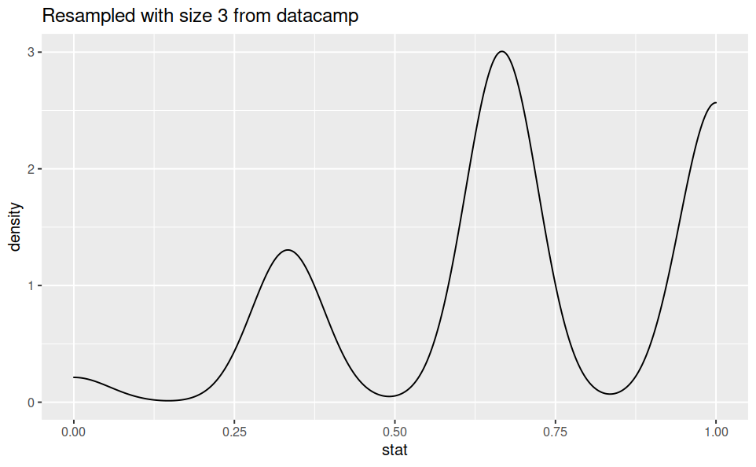

```r
ggplot(one_poll_boot_3_dput, aes(stat)) +
  geom_density() +
  ggtitle("Resampled with size 3 from datacamp")
```

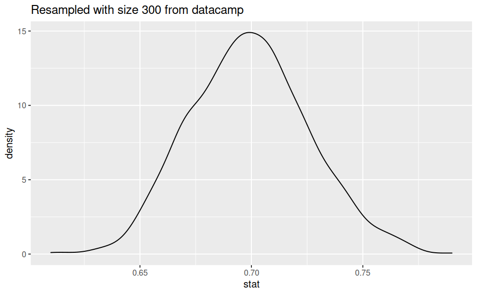

```r
ggplot(one_poll_boot_300_dput, aes(stat)) +
  geom_density() +
  ggtitle("Resampled with size 300 from datacamp")
```